# Risk Factor Analysis

## Outcome Variable

**Outcome Variable:** ever_stunted

## Predictor Variables

**Intervention Variable:** tr

**Adjustment Set:**

unadjusted

## Stratifying Variables

The analysis was stratified on these variable(s):

- single
- agecat
- studyid
- country

## Data Summary

| single | agecat | studyid | country | tr | ever_stunted | n_cell | n |
| --- | --- | --- | --- | --- | --- | --- | --- |
| 0 | 0-6 months | ki1066203-TanzaniaChild2 | TANZANIA, UNITED REPUBLIC OF | Control | 0 | 463 | 2012 |
| 0 | 0-6 months | ki1066203-TanzaniaChild2 | TANZANIA, UNITED REPUBLIC OF | Control | 1 | 34 | 2012 |
| 0 | 0-6 months | ki1066203-TanzaniaChild2 | TANZANIA, UNITED REPUBLIC OF | Other | 0 | 470 | 2012 |
| 0 | 0-6 months | ki1066203-TanzaniaChild2 | TANZANIA, UNITED REPUBLIC OF | Other | 1 | 34 | 2012 |
| 0 | 0-6 months | ki1066203-TanzaniaChild2 | TANZANIA, UNITED REPUBLIC OF | Zinc | 0 | 933 | 2012 |
| 0 | 0-6 months | ki1066203-TanzaniaChild2 | TANZANIA, UNITED REPUBLIC OF | Zinc | 1 | 78 | 2012 |
| 1 | 0-6 months | ki1066203-TanzaniaChild2 | TANZANIA, UNITED REPUBLIC OF | Control | 0 | 48 | 204 |
| 1 | 0-6 months | ki1066203-TanzaniaChild2 | TANZANIA, UNITED REPUBLIC OF | Control | 1 | 6 | 204 |
| 1 | 0-6 months | ki1066203-TanzaniaChild2 | TANZANIA, UNITED REPUBLIC OF | Other | 0 | 46 | 204 |
| 1 | 0-6 months | ki1066203-TanzaniaChild2 | TANZANIA, UNITED REPUBLIC OF | Other | 1 | 1 | 204 |
| 1 | 0-6 months | ki1066203-TanzaniaChild2 | TANZANIA, UNITED REPUBLIC OF | Zinc | 0 | 99 | 204 |
| 1 | 0-6 months | ki1066203-TanzaniaChild2 | TANZANIA, UNITED REPUBLIC OF | Zinc | 1 | 4 | 204 |
| 0 | 0-6 months | ki1112895-Guatemala BSC | GUATEMALA | Control | 0 | 79 | 211 |
| 0 | 0-6 months | ki1112895-Guatemala BSC | GUATEMALA | Control | 1 | 26 | 211 |
| 0 | 0-6 months | ki1112895-Guatemala BSC | GUATEMALA | Other | 0 | 88 | 211 |
| 0 | 0-6 months | ki1112895-Guatemala BSC | GUATEMALA | Other | 1 | 18 | 211 |
| 1 | 0-6 months | ki1112895-Guatemala BSC | GUATEMALA | Control | 0 | 7 | 25 |
| 1 | 0-6 months | ki1112895-Guatemala BSC | GUATEMALA | Control | 1 | 4 | 25 |
| 1 | 0-6 months | ki1112895-Guatemala BSC | GUATEMALA | Other | 0 | 7 | 25 |
| 1 | 0-6 months | ki1112895-Guatemala BSC | GUATEMALA | Other | 1 | 7 | 25 |
| 0 | 0-6 months | ki1119695-PROBIT | BELARUS | Control | 0 | 7022 | 15530 |
| 0 | 0-6 months | ki1119695-PROBIT | BELARUS | Control | 1 | 505 | 15530 |
| 0 | 0-6 months | ki1119695-PROBIT | BELARUS | Maternal | 0 | 7517 | 15530 |
| 0 | 0-6 months | ki1119695-PROBIT | BELARUS | Maternal | 1 | 486 | 15530 |
| 1 | 0-6 months | ki1119695-PROBIT | BELARUS | Control | 0 | 252 | 655 |
| 1 | 0-6 months | ki1119695-PROBIT | BELARUS | Control | 1 | 28 | 655 |
| 1 | 0-6 months | ki1119695-PROBIT | BELARUS | Maternal | 0 | 342 | 655 |
| 1 | 0-6 months | ki1119695-PROBIT | BELARUS | Maternal | 1 | 33 | 655 |
| 0 | 0-6 months | ki1126311-ZVITAMBO | ZIMBABWE | Control | 0 | 1775 | 8505 |
| 0 | 0-6 months | ki1126311-ZVITAMBO | ZIMBABWE | Control | 1 | 360 | 8505 |

[output cut: 174 more lines]

The following strata were considered:

- single: 0, agecat: 0-24 months, studyid: iLiNS_DYADM_LNS, country: MALAWI
- single: 0, agecat: 0-24 months, studyid: ki1066203-TanzaniaChild2, country: TANZANIA, UNITED REPUBLIC OF
- single: 0, agecat: 0-24 months, studyid: ki1112895-Guatemala BSC, country: GUATEMALA
- single: 0, agecat: 0-24 months, studyid: ki1119695-PROBIT, country: BELARUS
- single: 0, agecat: 0-24 months, studyid: ki1126311-ZVITAMBO, country: ZIMBABWE
- single: 0, agecat: 0-24 months, studyid: ki1135781-COHORTS, country: GUATEMALA
- single: 0, agecat: 0-24 months, studyid: ki1148112-iLiNS-DOSE, country: MALAWI
- single: 0, agecat: 0-24 months, studyid: ki1148112-iLiNS-DYAD-M, country: MALAWI
- single: 0, agecat: 0-6 months, studyid: iLiNS_DYADM_LNS, country: MALAWI
- single: 0, agecat: 0-6 months, studyid: ki1066203-TanzaniaChild2, country: TANZANIA, UNITED REPUBLIC OF
- single: 0, agecat: 0-6 months, studyid: ki1112895-Guatemala BSC, country: GUATEMALA
- single: 0, agecat: 0-6 months, studyid: ki1119695-PROBIT, country: BELARUS
- single: 0, agecat: 0-6 months, studyid: ki1126311-ZVITAMBO, country: ZIMBABWE
- single: 0, agecat: 0-6 months, studyid: ki1135781-COHORTS, country: GUATEMALA
- single: 0, agecat: 0-6 months, studyid: ki1148112-iLiNS-DOSE, country: MALAWI
- single: 0, agecat: 0-6 months, studyid: ki1148112-iLiNS-DYAD-M, country: MALAWI
- single: 0, agecat: 6-24 months, studyid: iLiNS_DYADM_LNS, country: MALAWI
- single: 0, agecat: 6-24 months, studyid: ki1066203-TanzaniaChild2, country: TANZANIA, UNITED REPUBLIC OF
- single: 0, agecat: 6-24 months, studyid: ki1112895-Guatemala BSC, country: GUATEMALA
- single: 0, agecat: 6-24 months, studyid: ki1119695-PROBIT, country: BELARUS
- single: 0, agecat: 6-24 months, studyid: ki1126311-ZVITAMBO, country: ZIMBABWE
- single: 0, agecat: 6-24 months, studyid: ki1135781-COHORTS, country: GUATEMALA
- single: 0, agecat: 6-24 months, studyid: ki1148112-iLiNS-DOSE, country: MALAWI
- single: 0, agecat: 6-24 months, studyid: ki1148112-iLiNS-DYAD-M, country: MALAWI
- single: 1, agecat: 0-24 months, studyid: iLiNS_DYADM_LNS, country: MALAWI
- single: 1, agecat: 0-24 months, studyid: ki1066203-TanzaniaChild2, country: TANZANIA, UNITED REPUBLIC OF
- single: 1, agecat: 0-24 months, studyid: ki1112895-Guatemala BSC, country: GUATEMALA
- single: 1, agecat: 0-24 months, studyid: ki1119695-PROBIT, country: BELARUS
- single: 1, agecat: 0-24 months, studyid: ki1126311-ZVITAMBO, country: ZIMBABWE
- single: 1, agecat: 0-24 months, studyid: ki1135781-COHORTS, country: GUATEMALA
- single: 1, agecat: 0-24 months, studyid: ki1148112-iLiNS-DOSE, country: MALAWI
- single: 1, agecat: 0-24 months, studyid: ki1148112-iLiNS-DYAD-M, country: MALAWI
- single: 1, agecat: 0-6 months, studyid: iLiNS_DYADM_LNS, country: MALAWI
- single: 1, agecat: 0-6 months, studyid: ki1066203-TanzaniaChild2, country: TANZANIA, UNITED REPUBLIC OF
- single: 1, agecat: 0-6 months, studyid: ki1112895-Guatemala BSC, country: GUATEMALA
- single: 1, agecat: 0-6 months, studyid: ki1119695-PROBIT, country: BELARUS
- single: 1, agecat: 0-6 months, studyid: ki1126311-ZVITAMBO, country: ZIMBABWE
- single: 1, agecat: 0-6 months, studyid: ki1135781-COHORTS, country: GUATEMALA
- single: 1, agecat: 0-6 months, studyid: ki1148112-iLiNS-DOSE, country: MALAWI
- single: 1, agecat: 0-6 months, studyid: ki1148112-iLiNS-DYAD-M, country: MALAWI
- single: 1, agecat: 6-24 months, studyid: iLiNS_DYADM_LNS, country: MALAWI
- single: 1, agecat: 6-24 months, studyid: ki1066203-TanzaniaChild2, country: TANZANIA, UNITED REPUBLIC OF
- single: 1, agecat: 6-24 months, studyid: ki1112895-Guatemala BSC, country: GUATEMALA
- single: 1, agecat: 6-24 months, studyid: ki1119695-PROBIT, country: BELARUS
- single: 1, agecat: 6-24 months, studyid: ki1126311-ZVITAMBO, country: ZIMBABWE
- single: 1, agecat: 6-24 months, studyid: ki1135781-COHORTS, country: GUATEMALA
- single: 1, agecat: 6-24 months, studyid: ki1148112-iLiNS-DOSE, country: MALAWI
- single: 1, agecat: 6-24 months, studyid: ki1148112-iLiNS-DYAD-M, country: MALAWI

### Dropped Strata

Some strata were dropped due to rare outcomes:

- single: 1, agecat: 0-6 months, studyid: ki1066203-TanzaniaChild2, country: TANZANIA, UNITED REPUBLIC OF
- single: 1, agecat: 0-6 months, studyid: ki1112895-Guatemala BSC, country: GUATEMALA
- single: 1, agecat: 0-6 months, studyid: ki1135781-COHORTS, country: GUATEMALA
- single: 0, agecat: 0-6 months, studyid: ki1148112-iLiNS-DYAD-M, country: MALAWI
- single: 1, agecat: 0-6 months, studyid: ki1148112-iLiNS-DYAD-M, country: MALAWI
- single: 1, agecat: 6-24 months, studyid: ki1112895-Guatemala BSC, country: GUATEMALA
- single: 1, agecat: 0-24 months, studyid: ki1112895-Guatemala BSC, country: GUATEMALA
- single: 1, agecat: 0-24 months, studyid: ki1135781-COHORTS, country: GUATEMALA
- single: 0, agecat: 0-6 months, studyid: iLiNS_DYADM_LNS, country: MALAWI
- single: 1, agecat: 0-6 months, studyid: iLiNS_DYADM_LNS, country: MALAWI

## Methods Detail

We’re interested in the causal parameters $E[Y_a]$ for all values of $a \in \mathcal{A}$. These parameters represent the mean outcome if, possibly contrary to fact, we intervened to set all units to have $A=a$. Under the randomization and positivity assumptions, these are identified by the statistical parameters $\psi_a=E_W[E_{Y|A,W}(Y|A=a,W)]$. In addition, we’re interested in the mean of $Y$, $E[Y]$ under no intervention (the observed mean). We will estimate these parameters by using SuperLearner to fit the relevant likelihood factors – $E_{Y|A,W}(Y|A=a,W)$ and $p(A=a|W)$, and then updating our likelihood fit using a joint TMLE.

For unadjusted analyses ($W=\{\}$), initial likelihoods were estimated using Lrnr_glm to estimate the simple $E(Y|A)$ and Lrnr_mean to estimate $p(A)$. For adjusted analyses, a small library containing Lrnr_glmnet, Lrnr_xgboost, and Lrnr_mean was used.

Having estimated these parameters, we will then use the delta method to estimate relative risks and attributable risks relative to a prespecified baseline level of $A$.

# Results Detail

## Results Plots

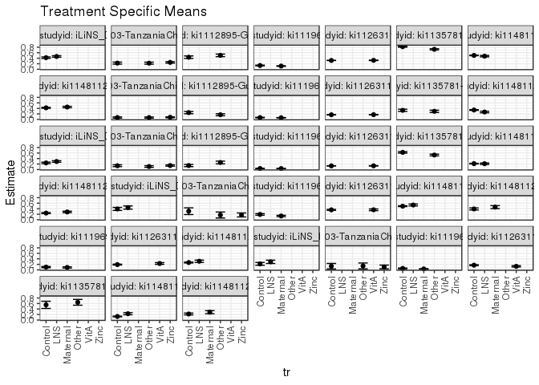

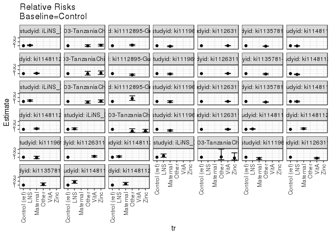

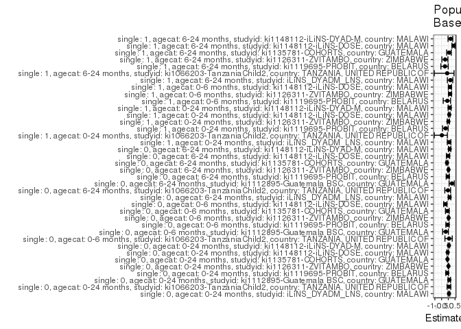

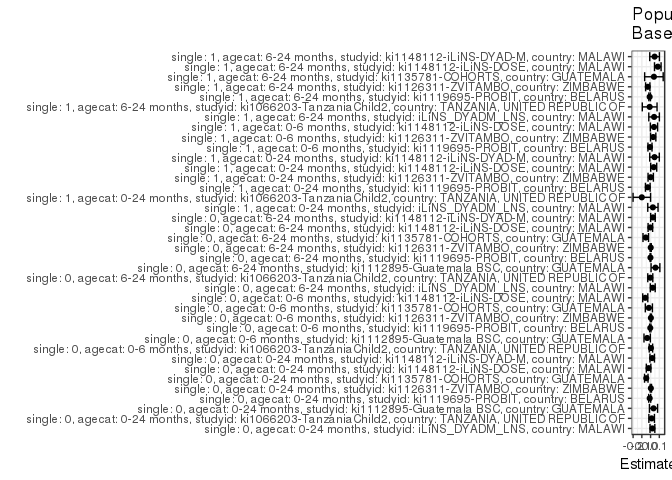

## Results Table

### Parameter: TSM

| single | agecat | studyid | country | intervention_level | baseline_level | estimate | ci_lower | ci_upper |
| --- | --- | --- | --- | --- | --- | --- | --- | --- |
| 0 | 0-24 months | iLiNS_DYADM_LNS | MALAWI | Control | NA | 0.4205607 | 0.3927583 | 0.4483632 |
| 0 | 0-24 months | iLiNS_DYADM_LNS | MALAWI | LNS | NA | 0.4638158 | 0.4365223 | 0.4911092 |
| 0 | 0-24 months | ki1066203-TanzaniaChild2 | TANZANIA, UNITED REPUBLIC OF | Control | NA | 0.2235529 | 0.1870622 | 0.2600436 |
| 0 | 0-24 months | ki1066203-TanzaniaChild2 | TANZANIA, UNITED REPUBLIC OF | Other | NA | 0.2204724 | 0.1844132 | 0.2565316 |
| 0 | 0-24 months | ki1066203-TanzaniaChild2 | TANZANIA, UNITED REPUBLIC OF | Zinc | NA | 0.2495108 | 0.2229741 | 0.2760474 |
| 0 | 0-24 months | ki1112895-Guatemala BSC | GUATEMALA | Control | NA | 0.4375000 | 0.3916655 | 0.4833345 |
| 0 | 0-24 months | ki1112895-Guatemala BSC | GUATEMALA | Other | NA | 0.5044248 | 0.4580240 | 0.5508255 |
| 0 | 0-24 months | ki1119695-PROBIT | BELARUS | Control | NA | 0.1363695 | 0.1228341 | 0.1499049 |
| 0 | 0-24 months | ki1119695-PROBIT | BELARUS | Maternal | NA | 0.1167329 | 0.1060534 | 0.1274124 |
| 0 | 0-24 months | ki1126311-ZVITAMBO | ZIMBABWE | Control | NA | 0.3196692 | 0.3153005 | 0.3240378 |
| 0 | 0-24 months | ki1126311-ZVITAMBO | ZIMBABWE | VitA | NA | 0.3238822 | 0.3163305 | 0.3314339 |
| 0 | 0-24 months | ki1135781-COHORTS | GUATEMALA | Control | NA | 0.8178138 | 0.8015909 | 0.8340366 |
| 0 | 0-24 months | ki1135781-COHORTS | GUATEMALA | Other | NA | 0.7237569 | 0.7040544 | 0.7434594 |
| 0 | 0-24 months | ki1148112-iLiNS-DOSE | MALAWI | Control | NA | 0.5025126 | 0.4910164 | 0.5140088 |
| 0 | 0-24 months | ki1148112-iLiNS-DOSE | MALAWI | LNS | NA | 0.4750996 | 0.4493090 | 0.5008902 |
| 0 | 0-24 months | ki1148112-iLiNS-DYAD-M | MALAWI | Control | NA | 0.4205607 | 0.4020109 | 0.4391106 |
| 0 | 0-24 months | ki1148112-iLiNS-DYAD-M | MALAWI | Maternal | NA | 0.4487805 | 0.4229283 | 0.4746327 |
| 0 | 0-6 months | ki1066203-TanzaniaChild2 | TANZANIA, UNITED REPUBLIC OF | Control | NA | 0.0684105 | 0.0462105 | 0.0906104 |
| 0 | 0-6 months | ki1066203-TanzaniaChild2 | TANZANIA, UNITED REPUBLIC OF | Other | NA | 0.0674603 | 0.0455576 | 0.0893631 |
| 0 | 0-6 months | ki1066203-TanzaniaChild2 | TANZANIA, UNITED REPUBLIC OF | Zinc | NA | 0.0771513 | 0.0606994 | 0.0936033 |
| 0 | 0-6 months | ki1112895-Guatemala BSC | GUATEMALA | Control | NA | 0.2476190 | 0.2064375 | 0.2888006 |
| 0 | 0-6 months | ki1112895-Guatemala BSC | GUATEMALA | Other | NA | 0.1698113 | 0.1338180 | 0.2058046 |
| 0 | 0-6 months | ki1119695-PROBIT | BELARUS | Control | NA | 0.0670918 | 0.0580251 | 0.0761585 |
| 0 | 0-6 months | ki1119695-PROBIT | BELARUS | Maternal | NA | 0.0607272 | 0.0534725 | 0.0679820 |
| 0 | 0-6 months | ki1126311-ZVITAMBO | ZIMBABWE | Control | NA | 0.1686183 | 0.1646312 | 0.1726053 |
| 0 | 0-6 months | ki1126311-ZVITAMBO | ZIMBABWE | VitA | NA | 0.1731554 | 0.1661956 | 0.1801153 |
| 0 | 0-6 months | ki1135781-COHORTS | GUATEMALA | Control | NA | 0.3305785 | 0.2905701 | 0.3705869 |
| 0 | 0-6 months | ki1135781-COHORTS | GUATEMALA | Other | NA | 0.2932331 | 0.2526410 | 0.3338252 |
| 0 | 0-6 months | ki1148112-iLiNS-DOSE | MALAWI | Control | NA | 0.3414634 | 0.3278738 | 0.3550530 |
| 0 | 0-6 months | ki1148112-iLiNS-DOSE | MALAWI | LNS | NA | 0.2688679 | 0.2399752 | 0.2977607 |

[output cut: 51 more lines]

### Parameter: E(Y)

| single | agecat | studyid | country | intervention_level | baseline_level | estimate | ci_lower | ci_upper |
| --- | --- | --- | --- | --- | --- | --- | --- | --- |
| 0 | 0-24 months | iLiNS_DYADM_LNS | MALAWI | NA | NA | 0.4416000 | 0.4026001 | 0.4805999 |
| 0 | 0-24 months | ki1066203-TanzaniaChild2 | TANZANIA, UNITED REPUBLIC OF | NA | NA | 0.2358444 | 0.2173771 | 0.2543117 |
| 0 | 0-24 months | ki1112895-Guatemala BSC | GUATEMALA | NA | NA | 0.4711111 | 0.4057427 | 0.5364795 |
| 0 | 0-24 months | ki1119695-PROBIT | BELARUS | NA | NA | 0.1262148 | 0.1078546 | 0.1445750 |
| 0 | 0-24 months | ki1126311-ZVITAMBO | ZIMBABWE | NA | NA | 0.3228204 | 0.3140960 | 0.3315447 |
| 0 | 0-24 months | ki1135781-COHORTS | GUATEMALA | NA | NA | 0.7685632 | 0.7428814 | 0.7942449 |
| 0 | 0-24 months | ki1148112-iLiNS-DOSE | MALAWI | NA | NA | 0.4796342 | 0.4513916 | 0.5078769 |
| 0 | 0-24 months | ki1148112-iLiNS-DYAD-M | MALAWI | NA | NA | 0.4391026 | 0.4072716 | 0.4709335 |
| 0 | 0-6 months | ki1066203-TanzaniaChild2 | TANZANIA, UNITED REPUBLIC OF | NA | NA | 0.0725646 | 0.0612264 | 0.0839029 |
| 0 | 0-6 months | ki1112895-Guatemala BSC | GUATEMALA | NA | NA | 0.2085308 | 0.1535842 | 0.2634774 |
| 0 | 0-6 months | ki1119695-PROBIT | BELARUS | NA | NA | 0.0638120 | 0.0519542 | 0.0756697 |
| 0 | 0-6 months | ki1126311-ZVITAMBO | ZIMBABWE | NA | NA | 0.1720165 | 0.1639954 | 0.1800375 |
| 0 | 0-6 months | ki1135781-COHORTS | GUATEMALA | NA | NA | 0.3110236 | 0.2539827 | 0.3680646 |
| 0 | 0-6 months | ki1148112-iLiNS-DOSE | MALAWI | NA | NA | 0.2806324 | 0.2486466 | 0.3126183 |
| 0 | 6-24 months | iLiNS_DYADM_LNS | MALAWI | NA | NA | 0.2661290 | 0.2271331 | 0.3051250 |
| 0 | 6-24 months | ki1066203-TanzaniaChild2 | TANZANIA, UNITED REPUBLIC OF | NA | NA | 0.1359807 | 0.1194967 | 0.1524648 |
| 0 | 6-24 months | ki1112895-Guatemala BSC | GUATEMALA | NA | NA | 0.2026144 | 0.1387151 | 0.2665136 |
| 0 | 6-24 months | ki1119695-PROBIT | BELARUS | NA | NA | 0.0378420 | 0.0283816 | 0.0473023 |
| 0 | 6-24 months | ki1126311-ZVITAMBO | ZIMBABWE | NA | NA | 0.1360046 | 0.1288155 | 0.1431937 |
| 0 | 6-24 months | ki1135781-COHORTS | GUATEMALA | NA | NA | 0.5693431 | 0.5278470 | 0.6108392 |
| 0 | 6-24 months | ki1148112-iLiNS-DOSE | MALAWI | NA | NA | 0.2128463 | 0.1843575 | 0.2413352 |
| 0 | 6-24 months | ki1148112-iLiNS-DYAD-M | MALAWI | NA | NA | 0.2682603 | 0.2365597 | 0.2999609 |
| 1 | 0-24 months | iLiNS_DYADM_LNS | MALAWI | NA | NA | 0.4178082 | 0.3375322 | 0.4980842 |
| 1 | 0-24 months | ki1066203-TanzaniaChild2 | TANZANIA, UNITED REPUBLIC OF | NA | NA | 0.2087379 | 0.1531049 | 0.2643708 |
| 1 | 0-24 months | ki1119695-PROBIT | BELARUS | NA | NA | 0.1595900 | 0.1202158 | 0.1989643 |
| 1 | 0-24 months | ki1126311-ZVITAMBO | ZIMBABWE | NA | NA | 0.3598901 | 0.3250007 | 0.3947795 |
| 1 | 0-24 months | ki1148112-iLiNS-DOSE | MALAWI | NA | NA | 0.5267062 | 0.4889846 | 0.5644278 |
| 1 | 0-24 months | ki1148112-iLiNS-DYAD-M | MALAWI | NA | NA | 0.4363636 | 0.3706811 | 0.5020462 |
| 1 | 0-6 months | ki1119695-PROBIT | BELARUS | NA | NA | 0.0931298 | 0.0608027 | 0.1254569 |
| 1 | 0-6 months | ki1126311-ZVITAMBO | ZIMBABWE | NA | NA | 0.2214286 | 0.1870088 | 0.2558484 |
| 1 | 0-6 months | ki1148112-iLiNS-DOSE | MALAWI | NA | NA | 0.3056235 | 0.2609233 | 0.3503236 |
| 1 | 6-24 months | iLiNS_DYADM_LNS | MALAWI | NA | NA | 0.2583333 | 0.1796887 | 0.3369780 |
| 1 | 6-24 months | ki1066203-TanzaniaChild2 | TANZANIA, UNITED REPUBLIC OF | NA | NA | 0.1228070 | 0.0734689 | 0.1721452 |
| 1 | 6-24 months | ki1119695-PROBIT | BELARUS | NA | NA | 0.0424886 | 0.0254870 | 0.0594902 |
| 1 | 6-24 months | ki1126311-ZVITAMBO | ZIMBABWE | NA | NA | 0.1381215 | 0.1090745 | 0.1671686 |
| 1 | 6-24 months | ki1135781-COHORTS | GUATEMALA | NA | NA | 0.5882353 | 0.4203196 | 0.7561510 |
| 1 | 6-24 months | ki1148112-iLiNS-DOSE | MALAWI | NA | NA | 0.2110553 | 0.1709156 | 0.2511950 |
| 1 | 6-24 months | ki1148112-iLiNS-DYAD-M | MALAWI | NA | NA | 0.2640449 | 0.1991029 | 0.3289870 |

### Parameter: RR

| single | agecat | studyid | country | intervention_level | baseline_level | estimate | ci_lower | ci_upper |
| --- | --- | --- | --- | --- | --- | --- | --- | --- |
| 0 | 0-24 months | iLiNS_DYADM_LNS | MALAWI | Control | Control | 1.0000000 | 1.0000000 | 1.0000000 |
| 0 | 0-24 months | iLiNS_DYADM_LNS | MALAWI | LNS | Control | 1.1028509 | 1.0094383 | 1.2049078 |
| 0 | 0-24 months | ki1066203-TanzaniaChild2 | TANZANIA, UNITED REPUBLIC OF | Control | Control | 1.0000000 | 1.0000000 | 1.0000000 |
| 0 | 0-24 months | ki1066203-TanzaniaChild2 | TANZANIA, UNITED REPUBLIC OF | Other | Control | 0.9862205 | 0.7827458 | 1.2425884 |
| 0 | 0-24 months | ki1066203-TanzaniaChild2 | TANZANIA, UNITED REPUBLIC OF | Zinc | Control | 1.1161151 | 0.9185417 | 1.3561856 |
| 0 | 0-24 months | ki1112895-Guatemala BSC | GUATEMALA | Control | Control | 1.0000000 | 1.0000000 | 1.0000000 |
| 0 | 0-24 months | ki1112895-Guatemala BSC | GUATEMALA | Other | Control | 1.1529709 | 1.0029286 | 1.3254602 |
| 0 | 0-24 months | ki1119695-PROBIT | BELARUS | Control | Control | 1.0000000 | 1.0000000 | 1.0000000 |
| 0 | 0-24 months | ki1119695-PROBIT | BELARUS | Maternal | Control | 0.8560046 | 0.7487271 | 0.9786529 |
| 0 | 0-24 months | ki1126311-ZVITAMBO | ZIMBABWE | Control | Control | 1.0000000 | 1.0000000 | 1.0000000 |
| 0 | 0-24 months | ki1126311-ZVITAMBO | ZIMBABWE | VitA | Control | 1.0131794 | 0.9861638 | 1.0409350 |
| 0 | 0-24 months | ki1135781-COHORTS | GUATEMALA | Control | Control | 1.0000000 | 1.0000000 | 1.0000000 |
| 0 | 0-24 months | ki1135781-COHORTS | GUATEMALA | Other | Control | 0.8849899 | 0.8556769 | 0.9153070 |
| 0 | 0-24 months | ki1148112-iLiNS-DOSE | MALAWI | Control | Control | 1.0000000 | 1.0000000 | 1.0000000 |
| 0 | 0-24 months | ki1148112-iLiNS-DOSE | MALAWI | LNS | Control | 0.9454482 | 0.8913622 | 1.0028161 |
| 0 | 0-24 months | ki1148112-iLiNS-DYAD-M | MALAWI | Control | Control | 1.0000000 | 1.0000000 | 1.0000000 |
| 0 | 0-24 months | ki1148112-iLiNS-DYAD-M | MALAWI | Maternal | Control | 1.0671003 | 0.9924214 | 1.1473986 |
| 0 | 0-6 months | ki1066203-TanzaniaChild2 | TANZANIA, UNITED REPUBLIC OF | Control | Control | 1.0000000 | 1.0000000 | 1.0000000 |
| 0 | 0-6 months | ki1066203-TanzaniaChild2 | TANZANIA, UNITED REPUBLIC OF | Other | Control | 0.9861111 | 0.6231110 | 1.5605808 |
| 0 | 0-6 months | ki1066203-TanzaniaChild2 | TANZANIA, UNITED REPUBLIC OF | Zinc | Control | 1.1277710 | 0.7648617 | 1.6628725 |
| 0 | 0-6 months | ki1112895-Guatemala BSC | GUATEMALA | Control | Control | 1.0000000 | 1.0000000 | 1.0000000 |
| 0 | 0-6 months | ki1112895-Guatemala BSC | GUATEMALA | Other | Control | 0.6857765 | 0.5238122 | 0.8978207 |
| 0 | 0-6 months | ki1119695-PROBIT | BELARUS | Control | Control | 1.0000000 | 1.0000000 | 1.0000000 |
| 0 | 0-6 months | ki1119695-PROBIT | BELARUS | Maternal | Control | 0.9051363 | 0.7562418 | 1.0833463 |
| 0 | 0-6 months | ki1126311-ZVITAMBO | ZIMBABWE | Control | Control | 1.0000000 | 1.0000000 | 1.0000000 |
| 0 | 0-6 months | ki1126311-ZVITAMBO | ZIMBABWE | VitA | Control | 1.0269078 | 0.9801191 | 1.0759302 |
| 0 | 0-6 months | ki1135781-COHORTS | GUATEMALA | Control | Control | 1.0000000 | 1.0000000 | 1.0000000 |
| 0 | 0-6 months | ki1135781-COHORTS | GUATEMALA | Other | Control | 0.8870301 | 0.7380447 | 1.0660904 |
| 0 | 0-6 months | ki1148112-iLiNS-DOSE | MALAWI | Control | Control | 1.0000000 | 1.0000000 | 1.0000000 |
| 0 | 0-6 months | ki1148112-iLiNS-DOSE | MALAWI | LNS | Control | 0.7873989 | 0.7021460 | 0.8830030 |

[output cut: 51 more lines]

### Parameter: PAR

| single | agecat | studyid | country | intervention_level | baseline_level | estimate | ci_lower | ci_upper |
| --- | --- | --- | --- | --- | --- | --- | --- | --- |
| 0 | 0-24 months | iLiNS_DYADM_LNS | MALAWI | Control | NA | 0.0210393 | -0.0063107 | 0.0483892 |
| 0 | 0-24 months | ki1066203-TanzaniaChild2 | TANZANIA, UNITED REPUBLIC OF | Control | NA | 0.0122915 | -0.0195782 | 0.0441612 |
| 0 | 0-24 months | ki1112895-Guatemala BSC | GUATEMALA | Control | NA | 0.0336111 | -0.0129961 | 0.0802183 |
| 0 | 0-24 months | ki1119695-PROBIT | BELARUS | Control | NA | -0.0101547 | -0.0217223 | 0.0014129 |
| 0 | 0-24 months | ki1126311-ZVITAMBO | ZIMBABWE | Control | NA | 0.0031512 | -0.0044006 | 0.0107030 |
| 0 | 0-24 months | ki1135781-COHORTS | GUATEMALA | Control | NA | -0.0492506 | -0.0691596 | -0.0293416 |
| 0 | 0-24 months | ki1148112-iLiNS-DOSE | MALAWI | Control | NA | -0.0228783 | -0.0486753 | 0.0029187 |
| 0 | 0-24 months | ki1148112-iLiNS-DYAD-M | MALAWI | Control | NA | 0.0185418 | -0.0073254 | 0.0444090 |
| 0 | 0-6 months | ki1066203-TanzaniaChild2 | TANZANIA, UNITED REPUBLIC OF | Control | NA | 0.0041541 | -0.0152859 | 0.0235942 |
| 0 | 0-6 months | ki1112895-Guatemala BSC | GUATEMALA | Control | NA | -0.0390882 | -0.0754641 | -0.0027124 |
| 0 | 0-6 months | ki1119695-PROBIT | BELARUS | Control | NA | -0.0032798 | -0.0106885 | 0.0041289 |
| 0 | 0-6 months | ki1126311-ZVITAMBO | ZIMBABWE | Control | NA | 0.0033982 | -0.0035618 | 0.0103582 |
| 0 | 0-6 months | ki1135781-COHORTS | GUATEMALA | Control | NA | -0.0195549 | -0.0602120 | 0.0211022 |
| 0 | 0-6 months | ki1148112-iLiNS-DOSE | MALAWI | Control | NA | -0.0608310 | -0.0897864 | -0.0318756 |
| 0 | 6-24 months | iLiNS_DYADM_LNS | MALAWI | Control | NA | 0.0248839 | -0.0030744 | 0.0528421 |
| 0 | 6-24 months | ki1066203-TanzaniaChild2 | TANZANIA, UNITED REPUBLIC OF | Control | NA | -0.0034423 | -0.0321717 | 0.0252870 |
| 0 | 6-24 months | ki1112895-Guatemala BSC | GUATEMALA | Control | NA | 0.0559477 | 0.0056227 | 0.1062727 |
| 0 | 6-24 months | ki1119695-PROBIT | BELARUS | Control | NA | -0.0012434 | -0.0055466 | 0.0030599 |
| 0 | 6-24 months | ki1126311-ZVITAMBO | ZIMBABWE | Control | NA | 0.0015546 | -0.0046695 | 0.0077787 |
| 0 | 6-24 months | ki1135781-COHORTS | GUATEMALA | Control | NA | -0.0551295 | -0.0869049 | -0.0233541 |
| 0 | 6-24 months | ki1148112-iLiNS-DOSE | MALAWI | Control | NA | -0.0025383 | -0.0285686 | 0.0234921 |
| 0 | 6-24 months | ki1148112-iLiNS-DYAD-M | MALAWI | Control | NA | 0.0270152 | 0.0008438 | 0.0531865 |
| 1 | 0-24 months | iLiNS_DYADM_LNS | MALAWI | Control | NA | 0.0265039 | -0.0323350 | 0.0853428 |
| 1 | 0-24 months | ki1066203-TanzaniaChild2 | TANZANIA, UNITED REPUBLIC OF | Control | NA | -0.1003530 | -0.2007517 | 0.0000456 |
| 1 | 0-24 months | ki1119695-PROBIT | BELARUS | Control | NA | -0.0321908 | -0.0588344 | -0.0055471 |
| 1 | 0-24 months | ki1126311-ZVITAMBO | ZIMBABWE | Control | NA | 0.0015086 | -0.0289632 | 0.0319805 |
| 1 | 0-24 months | ki1148112-iLiNS-DOSE | MALAWI | Control | NA | 0.0357971 | 0.0012992 | 0.0702950 |
| 1 | 0-24 months | ki1148112-iLiNS-DYAD-M | MALAWI | Control | NA | 0.0450593 | -0.0097479 | 0.0998665 |
| 1 | 0-6 months | ki1119695-PROBIT | BELARUS | Control | NA | -0.0068702 | -0.0301639 | 0.0164235 |
| 1 | 0-6 months | ki1126311-ZVITAMBO | ZIMBABWE | Control | NA | 0.0299392 | -0.0003401 | 0.0602186 |
| 1 | 0-6 months | ki1148112-iLiNS-DOSE | MALAWI | Control | NA | 0.0389568 | -0.0026124 | 0.0805260 |
| 1 | 6-24 months | iLiNS_DYADM_LNS | MALAWI | Control | NA | 0.0401515 | -0.0203562 | 0.1006592 |
| 1 | 6-24 months | ki1066203-TanzaniaChild2 | TANZANIA, UNITED REPUBLIC OF | Control | NA | -0.0105263 | -0.0949916 | 0.0739390 |
| 1 | 6-24 months | ki1119695-PROBIT | BELARUS | Control | NA | -0.0107029 | -0.0195044 | -0.0019014 |
| 1 | 6-24 months | ki1126311-ZVITAMBO | ZIMBABWE | Control | NA | -0.0324211 | -0.0570290 | -0.0078132 |
| 1 | 6-24 months | ki1135781-COHORTS | GUATEMALA | Control | NA | 0.0382353 | -0.0678216 | 0.1442922 |
| 1 | 6-24 months | ki1148112-iLiNS-DOSE | MALAWI | Control | NA | 0.0824838 | 0.0447941 | 0.1201736 |
| 1 | 6-24 months | ki1148112-iLiNS-DYAD-M | MALAWI | Control | NA | 0.0458631 | -0.0095766 | 0.1013029 |

### Parameter: PAF

| single | agecat | studyid | country | intervention_level | baseline_level | estimate | ci_lower | ci_upper |
| --- | --- | --- | --- | --- | --- | --- | --- | --- |
| 0 | 0-24 months | iLiNS_DYADM_LNS | MALAWI | Control | NA | 0.0476432 | -0.0132857 | 0.1049085 |
| 0 | 0-24 months | ki1066203-TanzaniaChild2 | TANZANIA, UNITED REPUBLIC OF | Control | NA | 0.0521171 | -0.0930903 | 0.1780349 |
| 0 | 0-24 months | ki1112895-Guatemala BSC | GUATEMALA | Control | NA | 0.0713443 | -0.0255152 | 0.1590555 |
| 0 | 0-24 months | ki1119695-PROBIT | BELARUS | Control | NA | -0.0804557 | -0.1851731 | 0.0150093 |
| 0 | 0-24 months | ki1126311-ZVITAMBO | ZIMBABWE | Control | NA | 0.0097614 | -0.0136768 | 0.0326578 |
| 0 | 0-24 months | ki1135781-COHORTS | GUATEMALA | Control | NA | -0.0640814 | -0.0920398 | -0.0368388 |
| 0 | 0-24 months | ki1148112-iLiNS-DOSE | MALAWI | Control | NA | -0.0476995 | -0.1056049 | 0.0071731 |
| 0 | 0-24 months | ki1148112-iLiNS-DYAD-M | MALAWI | Control | NA | 0.0422266 | -0.0159201 | 0.0970452 |
| 0 | 0-6 months | ki1066203-TanzaniaChild2 | TANZANIA, UNITED REPUBLIC OF | Control | NA | 0.0572476 | -0.2524235 | 0.2903502 |
| 0 | 0-6 months | ki1112895-Guatemala BSC | GUATEMALA | Control | NA | -0.1874459 | -0.4176595 | 0.0053833 |
| 0 | 0-6 months | ki1119695-PROBIT | BELARUS | Control | NA | -0.0513983 | -0.1812957 | 0.0642154 |
| 0 | 0-6 months | ki1126311-ZVITAMBO | ZIMBABWE | Control | NA | 0.0197551 | -0.0207227 | 0.0586276 |
| 0 | 0-6 months | ki1135781-COHORTS | GUATEMALA | Control | NA | -0.0628727 | -0.2115698 | 0.0675747 |
| 0 | 0-6 months | ki1148112-iLiNS-DOSE | MALAWI | Control | NA | -0.2167640 | -0.3494999 | -0.0970839 |
| 0 | 6-24 months | iLiNS_DYADM_LNS | MALAWI | Control | NA | 0.0935031 | -0.0074422 | 0.1843337 |
| 0 | 6-24 months | ki1066203-TanzaniaChild2 | TANZANIA, UNITED REPUBLIC OF | Control | NA | -0.0253148 | -0.2599142 | 0.1656015 |
| 0 | 6-24 months | ki1112895-Guatemala BSC | GUATEMALA | Control | NA | 0.2761290 | 0.0619352 | 0.4414147 |
| 0 | 6-24 months | ki1119695-PROBIT | BELARUS | Control | NA | -0.0328568 | -0.1576529 | 0.0784862 |
| 0 | 6-24 months | ki1126311-ZVITAMBO | ZIMBABWE | Control | NA | 0.0114305 | -0.0348623 | 0.0556525 |
| 0 | 6-24 months | ki1135781-COHORTS | GUATEMALA | Control | NA | -0.0968300 | -0.1599630 | -0.0371332 |
| 0 | 6-24 months | ki1148112-iLiNS-DOSE | MALAWI | Control | NA | -0.0119254 | -0.1435675 | 0.1045628 |
| 0 | 6-24 months | ki1148112-iLiNS-DYAD-M | MALAWI | Control | NA | 0.1007050 | 0.0082648 | 0.1845288 |
| 1 | 0-24 months | iLiNS_DYADM_LNS | MALAWI | Control | NA | 0.0634355 | -0.0784972 | 0.1866896 |
| 1 | 0-24 months | ki1066203-TanzaniaChild2 | TANZANIA, UNITED REPUBLIC OF | Control | NA | -0.4807611 | -1.0438684 | -0.0727958 |
| 1 | 0-24 months | ki1119695-PROBIT | BELARUS | Control | NA | -0.2017092 | -0.4236092 | -0.0143970 |
| 1 | 0-24 months | ki1126311-ZVITAMBO | ZIMBABWE | Control | NA | 0.0041919 | -0.0837957 | 0.0850362 |
| 1 | 0-24 months | ki1148112-iLiNS-DOSE | MALAWI | Control | NA | 0.0679641 | 0.0048408 | 0.1270836 |
| 1 | 0-24 months | ki1148112-iLiNS-DYAD-M | MALAWI | Control | NA | 0.1032609 | -0.0171171 | 0.2093918 |
| 1 | 0-6 months | ki1119695-PROBIT | BELARUS | Control | NA | -0.0737705 | -0.3796878 | 0.1643159 |
| 1 | 0-6 months | ki1126311-ZVITAMBO | ZIMBABWE | Control | NA | 0.1352093 | 0.0080027 | 0.2461039 |
| 1 | 0-6 months | ki1148112-iLiNS-DOSE | MALAWI | Control | NA | 0.1274667 | 0.0001134 | 0.2385993 |
| 1 | 6-24 months | iLiNS_DYADM_LNS | MALAWI | Control | NA | 0.1554252 | -0.0703863 | 0.3335989 |
| 1 | 6-24 months | ki1066203-TanzaniaChild2 | TANZANIA, UNITED REPUBLIC OF | Control | NA | -0.0857143 | -1.0445447 | 0.4234533 |
| 1 | 6-24 months | ki1119695-PROBIT | BELARUS | Control | NA | -0.2518997 | -0.5532547 | -0.0090121 |
| 1 | 6-24 months | ki1126311-ZVITAMBO | ZIMBABWE | Control | NA | -0.2347287 | -0.4773856 | -0.0319276 |
| 1 | 6-24 months | ki1135781-COHORTS | GUATEMALA | Control | NA | 0.0650000 | -0.1204643 | 0.2197654 |
| 1 | 6-24 months | ki1148112-iLiNS-DOSE | MALAWI | Control | NA | 0.3908163 | 0.2681584 | 0.4929166 |
| 1 | 6-24 months | ki1148112-iLiNS-DYAD-M | MALAWI | Control | NA | 0.1736944 | -0.0211119 | 0.3313358 |